# Intro to Plotting with Seaborn

### Why/when to use Seaborn over Matplotlib?

- Seaborn will make more (usually good) decisions for you.
- Use Seaborn for more concise code and to quickly create clean-looking visualizations.
  - Many Python visualization libraries like Seaborn are built on top of Matplotlib anyway.
- Matplotlib is powerful but I personally find myself using it for nit-picky customizations.
  - Knowing your way around in matplotlib will help style your seaborn plots too.

```python
# subplots / grid plots

# controlling colors
# modifying styles

# line, bar
# distributions: histograms, KD plots, box whisker, violin
# conditional plots using 1, 2, or 3 conditions
```

### Optional: create a reference table for color custom palettes

- RGB (Red, Green, Blue) color model describes how the three primary colors combine in any proportion to form any secondary color.
- You can specicy a color using RGB values with each R, G, and B values out of one. For example: (0/255, 107/255, 164/255).
- RGB Color Codes Chart - https://www.rapidtables.com/web/color/RGB_Color.html

```python
org_colors_dict = {'blue': {'cmyk': 'C100 M94 Y24 K20',
                  'color': 'blue',
                  'hex': '#232D69',
                  'pms': '662',
                  'rgb': 'R36 G45 B105',
                  'type': 'primary'},
                 'gray': {'cmyk': 'C65 M57 Y52 K29',
                  'color': 'gray',
                  'hex': '#555559',
                  'pms': 'Cool Gray 11',
                  'rgb': 'R85 G86 B90',
                  'type': 'secondary'},
                 'green': {'cmyk': 'C100 M12 Y85 K2',
                  'color': 'green',
                  'hex': '#00945E',
                  'pms': '340',
                  'rgb': 'R0 G148 B94',
                  'type': 'secondary'},
                 'lime': {'cmyk': 'R219 G228 B68',
                  'color': 'lime',
                  'hex': '#DBE444',
                  'pms': '380',
                  'rgb': 'R219 G229 B68',
                  'type': 'secondary'},
                 'orange': {'cmyk': 'C0 M70 Y83 K0',
                  'color': 'orange',
                  'hex': '#F36F25',
                  'pms': '158',
                  'rgb': 'R243 G112 B37',
                  'type': 'secondary'},
                 'red': {'cmyk': 'C14 M100 Y74 K4',
                  'color': 'red',
                  'hex': '#CB003D',
                  'pms': '1935',
                  'rgb': 'R203 G0 B61',
                  'type': 'secondary'},
                 'turquoise': {'cmyk': 'C75 M0 Y17 K0',
                  'color': 'turquoise',
                  'hex': '#23BDC3',
                  'pms': '3115',
                  'rgb': 'R35 G189 B195',
                  'type': 'primary'},
                 'yellow': {'cmyk': 'CO M18 Y100 K0',
                  'color': 'yellow',
                  'hex': '#FFCE00',
                  'pms': '116',
                  'rgb': 'R225 G206 B0',
                  'type': 'secondary'}}
```

```python
org_colors_dict['blue']
```

```
{'cmyk': 'C100 M94 Y24 K20',
 'color': 'blue',
 'hex': '#232D69',
 'pms': '662',
 'rgb': 'R36 G45 B105',
 'type': 'primary'}
```

```python
# display as table

import pandas as pd

org_colors_df = pd.DataFrame.from_dict(org_colors_dict, orient='index')
org_colors_df
```

|  | cmyk | color | hex | pms | rgb | type |
| --- | --- | --- | --- | --- | --- | --- |
| blue | C100 M94 Y24 K20 | blue | #232D69 | 662 | R36 G45 B105 | primary |
| gray | C65 M57 Y52 K29 | gray | #555559 | Cool Gray 11 | R85 G86 B90 | secondary |
| green | C100 M12 Y85 K2 | green | #00945E | 340 | R0 G148 B94 | secondary |
| lime | R219 G228 B68 | lime | #DBE444 | 380 | R219 G229 B68 | secondary |
| orange | C0 M70 Y83 K0 | orange | #F36F25 | 158 | R243 G112 B37 | secondary |
| red | C14 M100 Y74 K4 | red | #CB003D | 1935 | R203 G0 B61 | secondary |
| turquoise | C75 M0 Y17 K0 | turquoise | #23BDC3 | 3115 | R35 G189 B195 | primary |
| yellow | CO M18 Y100 K0 | yellow | #FFCE00 | 116 | R225 G206 B0 | secondary |

### Setting the color palette

```python
# store hex colors as a list

custom_palette = ['#23BDC3', #turquoise, primary
               '#555559', #gray
               '#F36F25', #orange
               '#00945E', #green
               '#232D69', #blue, primary
               '#DBE444', #lime
               '#CB003D', #red
               '#FFCE00'] #yellow

import matplotlib.pyplot as plt
plt.style.use('classic')
%matplotlib inline
import numpy as np
import pandas as pd
import seaborn as sns
```

```
seaborn default
custom palette
```

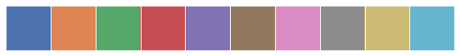

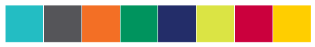

```python
# Experiment with "sns.set()" vs "sns.set_palette(custom_palette)"

print('seaborn default')
sns.set()
current_palette = sns.color_palette()
sns.palplot(current_palette)

print('custom palette')
sns.set_palette(custom_palette)
current_palette = sns.color_palette()
sns.palplot(current_palette)
```

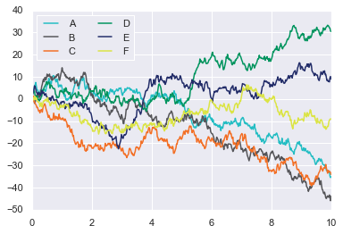

```python
# Create some data
rng = np.random.RandomState(0)
x = np.linspace(0, 10, 500)
y = np.cumsum(rng.randn(500, 6), 0)

# Plot the data with Matplotlib defaults
plt.plot(x, y)
plt.legend('ABCDEF', ncol=2, loc='upper left')
```

Context notes on numpy functions below:

- multivariate_normal is analogous to a 1-dimensional normal distribution - but for multiple dimensions inputs are mean, covariance, size
- covariance is analgous to standard deviation for a 1-dimensional normal distribution
- for more info, type: help(np.random.multivariate_normal)

```python
data = np.random.multivariate_normal([0, 0], [[5, 2], [2, 2]], size=2000)
data = pd.DataFrame(data, columns=['x', 'y'])
data.head()
```

|  | x | y |
| --- | --- | --- |
| 0 | 2.471662 | 1.417716 |
| 1 | -2.656838 | -1.682607 |
| 2 | -1.593397 | 1.103757 |
| 3 | -0.385164 | 1.363038 |
| 4 | -0.293121 | -0.475937 |

### Histogram Plot

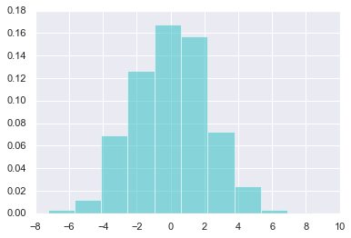

```python
plt.hist(data['x'], density=True, alpha=.5)
```

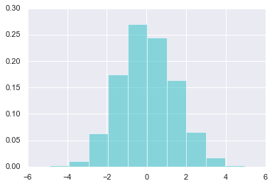

```python
plt.hist(data['y'], density=True, alpha=0.5)
```

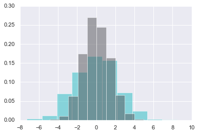

```python
# loop through columns to show multiple plots
# modify alpha for transparency

for col in 'xy':
    plt.hist(data[col], density=True, alpha=0.5)
```

### Kernel density plot

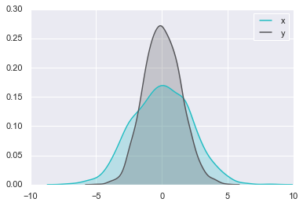

```python
# kernel density plots smooth out the distributions

for col in 'xy':
    sns.kdeplot(data[col], shade=True)
```

### Distribution plot

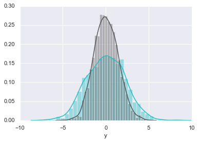

```python
sns.distplot(data['x'])
sns.distplot(data['y'])
```

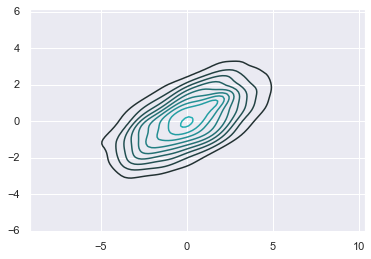

```python
sns.kdeplot(data)
```

### Joint distribution plot - KDE (kernel density)

Shading = concentration of both x & y

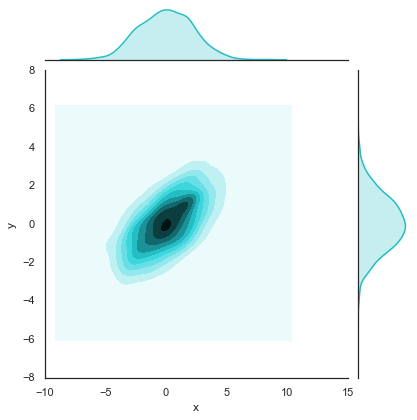

```python
with sns.axes_style('white'):
    sns.jointplot("x", "y", data, kind='kde')
```

### Joint distribution plot - hex

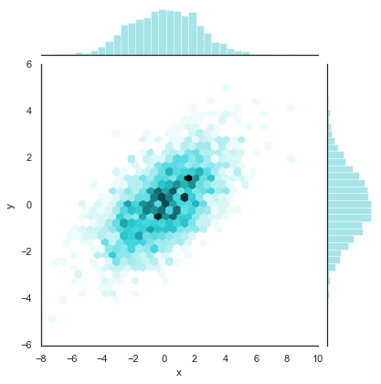

```python
with sns.axes_style('white'):
    sns.jointplot("x", "y", data, kind='hex')
```

### Pair plot

```python
# fyi: seaborn comes with preloaded data sets for demos that are available via sns.load_dataset()
# ex: 'iris', 'tips', 'planets'

iris = sns.load_dataset("iris")
iris.head()
```

|  | sepal_length | sepal_width | petal_length | petal_width | species |
| --- | --- | --- | --- | --- | --- |
| 0 | 5.1 | 3.5 | 1.4 | 0.2 | setosa |
| 1 | 4.9 | 3.0 | 1.4 | 0.2 | setosa |
| 2 | 4.7 | 3.2 | 1.3 | 0.2 | setosa |
| 3 | 4.6 | 3.1 | 1.5 | 0.2 | setosa |
| 4 | 5.0 | 3.6 | 1.4 | 0.2 | setosa |

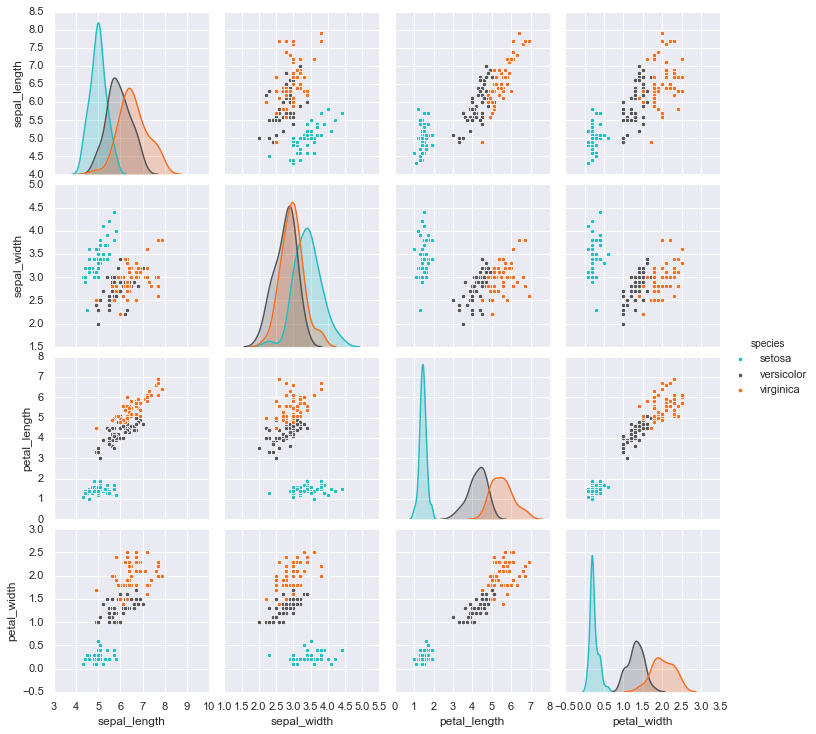

```python
sns.pairplot(iris, hue='species', size=2.5)
```

### Histogram - 2x2 Conditional

```python
tips = sns.load_dataset('tips')
tips['tip_pct'] = 100 * tips['tip'] / tips['total_bill']
tips.head()
```

|  | total_bill | tip | sex | smoker | day | time | size | tip_pct |
| --- | --- | --- | --- | --- | --- | --- | --- | --- |
| 0 | 16.99 | 1.01 | Female | No | Sun | Dinner | 2 | 5.944673 |
| 1 | 10.34 | 1.66 | Male | No | Sun | Dinner | 3 | 16.054159 |
| 2 | 21.01 | 3.50 | Male | No | Sun | Dinner | 3 | 16.658734 |
| 3 | 23.68 | 3.31 | Male | No | Sun | Dinner | 2 | 13.978041 |
| 4 | 24.59 | 3.61 | Female | No | Sun | Dinner | 4 | 14.680765 |

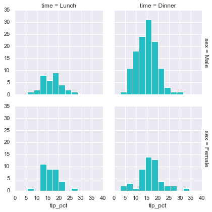

```python
grid = sns.FacetGrid(tips, row="sex", col="time", margin_titles=True)
grid.map(plt.hist, "tip_pct", bins=np.linspace(0, 40, 15))
```

### Box and Whisker - Conditional

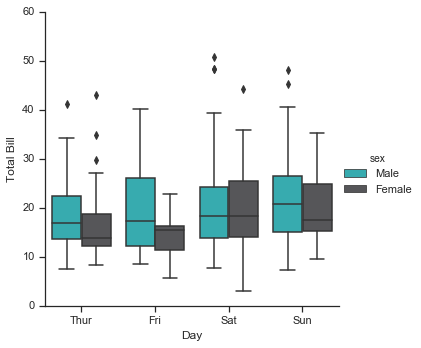

```python
with sns.axes_style(style='ticks'):
    g = sns.factorplot("day", "total_bill", "sex", data=tips, kind="box")
    g.set_axis_labels("Day", "Total Bill")
```

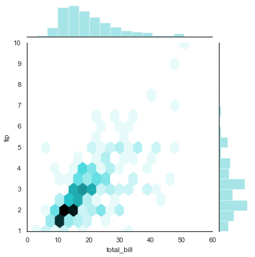

```python
with sns.axes_style('white'):
    sns.jointplot("total_bill", "tip", data=tips, kind='hex')
```

### Joint distribution - regression

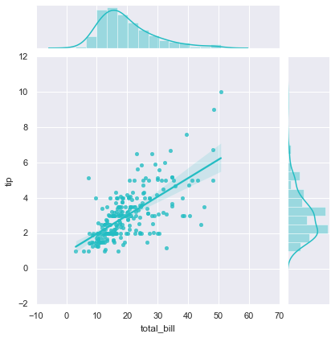

```python
sns.jointplot("total_bill", "tip", data=tips, kind='reg')
```

```python
planets = sns.load_dataset('planets')
planets.head()
```

|  | method | number | orbital_period | mass | distance | year |
| --- | --- | --- | --- | --- | --- | --- |
| 0 | Radial Velocity | 1 | 269.300 | 7.10 | 77.40 | 2006 |
| 1 | Radial Velocity | 1 | 874.774 | 2.21 | 56.95 | 2008 |
| 2 | Radial Velocity | 1 | 763.000 | 2.60 | 19.84 | 2011 |
| 3 | Radial Velocity | 1 | 326.030 | 19.40 | 110.62 | 2007 |
| 4 | Radial Velocity | 1 | 516.220 | 10.50 | 119.47 | 2009 |

### Bar graphs

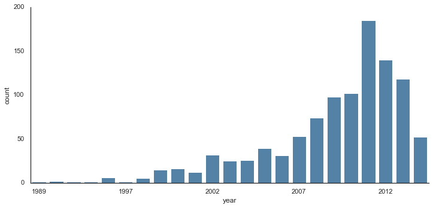

```python
with sns.axes_style('white'):
    g = sns.factorplot("year", data=planets, aspect=2,
                       kind="count", color='steelblue')
    g.set_xticklabels(step=5)
```

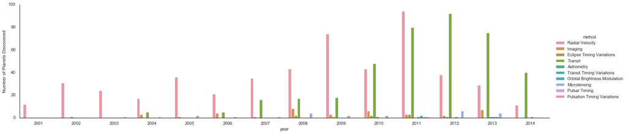

```python
with sns.axes_style('white'):
    g = sns.factorplot("year", data=planets, aspect=4.0, kind='count',
                       hue='method', order=range(2001, 2015))
    g.set_ylabels('Number of Planets Discovered')
```

# Introducing Seaborn

### Background on Titanic data set

The Titanic data set was compiled by Kaggle for their introductory data science competition, called Titanic: Machine Learning from Disaster. One major safety issue of the Titanic shipwreck was that there were not enough lifeboats for every passenger on board, which meant that some passengers were prioritized over others to use the lifeboats. The goal of the Kaggle competition is to build machine learning models that can predict if a passenger survives from their attributes. You can download the data set by navigating to the data download page for the competition and creating a free account.

https://www.kaggle.com/c/titanic/data

Tutorial Source: dataquest.io

```python
# pandas read_csv() takes URLs :)

titanic = pd.read_csv('https://raw.githubusercontent.com/paulzuradzki/seaborn-aesthetic-plots-demo/master/train.csv')
cols = ['Survived', 'Pclass', 'Sex', 'Age', 'SibSp', 'Parch', 'Fare', 'Embarked']
titanic = titanic[cols].dropna()
titanic.head()
```

|  | Survived | Pclass | Sex | Age | SibSp | Parch | Fare | Embarked |
| --- | --- | --- | --- | --- | --- | --- | --- | --- |
| 0 | 0 | 3 | male | 22.0 | 1 | 0 | 7.2500 | S |
| 1 | 1 | 1 | female | 38.0 | 1 | 0 | 71.2833 | C |
| 2 | 1 | 3 | female | 26.0 | 0 | 0 | 7.9250 | S |
| 3 | 1 | 1 | female | 35.0 | 1 | 0 | 53.1000 | S |
| 4 | 0 | 3 | male | 35.0 | 0 | 0 | 8.0500 | S |

Seaborn works similarly to the pyplot module from matplotlib. We primarily use seaborn interactively, by calling functions in its top level namespace. Like the pyplot module from matplotlib, seaborn creates a matplotlib figure or adds to the current, existing figure each time we generate a plot. When we're ready to display the plots, we call pyplot.show().

Under the hood, seaborn creates a histogram using matplotlib, scales the axes values, and styles it. In addition, seaborn uses a technique called kernel density estimation, or KDE for short, to create a smoothed line chart over the histogram.

What you need to know for now is that the resulting line is a smoother version of the histogram, called a kernel density plot. Kernel density plots are especially helpful when we're comparing distributions, which we'll explore later. When viewing a histogram, our visual processing systems influence us to smooth out the bars into a continuous line.

### Distribution plot

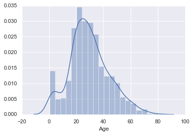

```python
import seaborn as sns
import matplotlib.pyplot as plt

# resets our styling and palette defined earlier
sns.set()

sns.distplot(titanic['Age'])
plt.show()
```

While having both the histogram and the kernel density plot is useful when we want to explore the data, it can be overwhelming for someone who's trying to understand the distribution. To generate just the kernel density plot, we use the seaborn.kdeplot() function.

While the distribution of data is displayed in a smoother fashion, it's now more difficult to visually estimate the area under the curve using just the line chart. When we also had the histogram, the bars provided a way to understand and compare proportions visually.

To bring back some of the ability to easily compare proportions, we can shade the area under the line using a single color. When calling the seaborn.kdeplot() function, we can shade the area under the line by setting the shade parameter to True.

### KDE only

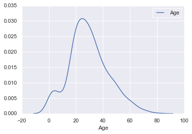

```python
sns.kdeplot(titanic['Age'])
plt.xlabel("Age")
plt.show()
```

### Shade

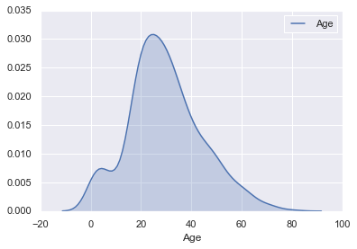

```python
sns.kdeplot(titanic['Age'], shade=True)
plt.xlabel("Age")
plt.show()
```

#### Style sheets, despine

We explored some general aesthetics guidelines for plots. The default seaborn style sheet gets some things right, like hiding axis ticks, and some things wrong, like displaying the coordinate grid and keeping all of the axis spines. We can use the seaborn.set_style() function to change the default seaborn style sheet. Seaborn comes with a few style sheets:

- darkgrid: Coordinate grid displayed, dark background color
- whitegrid: Coordinate grid displayed, white background color
- dark: Coordinate grid hidden, dark background color
- white: Coordinate grid hidden, white background color
- ticks: Coordinate grid hidden, white background color, ticks visible

If we change the style sheet using this method, all future plots will match that style in your current session. This means you need to set the style before generating the plot.

To remove the axis spines for the top and right axes, we use the seaborn.despine() function:

sns.despine()

By default, only the top and right axes will be despined, or have their spines removed. To despine the other two axes, we need to set the left and bottom parameters to True.

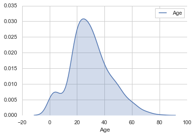

```python
sns.set_style('whitegrid')
sns.kdeplot(titanic['Age'], shade=True)
sns.despine(left=True, bottom=True)
plt.xlabel('Age')
```

### Annotating using Axes.text():

- First parameter = x coordinate.
- Second parameter = y coordinate.
- Third parameter = string of text.

### Resources

- Documentation for pyplot module - https://matplotlib.org/api/_as_gen/matplotlib.pyplot.plot.html
- Documentation for Axes.Text - https://matplotlib.org/api/_as_gen/matplotlib.axes.Axes.text.html

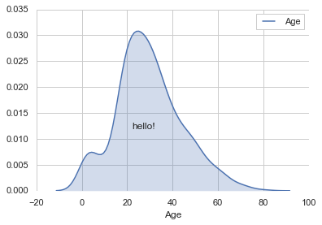

```python
sns.set_style('whitegrid')
sns.kdeplot(titanic['Age'], shade=True)
sns.despine(left=True, bottom=True)
plt.xlabel('Age')

plt.text(22, .012, 'hello!')
```

Here's what those plots look like:

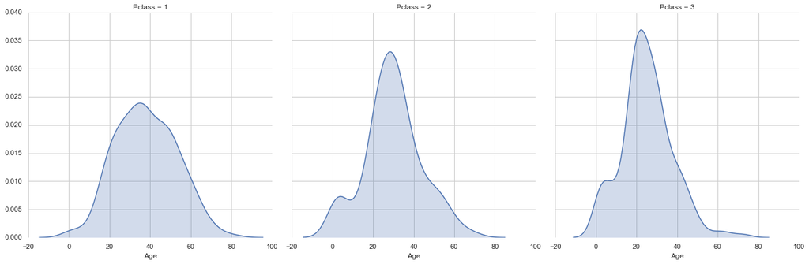

```python
g = sns.FacetGrid(titanic, col="Pclass", size=6)
g.map(sns.kdeplot, "Age", shade=True)
sns.despine(left=True, bottom=True)
plt.show()
```

We can use two conditions to generate a grid of plots, each containing a subset of the data with a unique combination of each condition. When creating a FacetGrid, we use the row parameter to specify the column in the dataframe we want used to subset across the rows in the grid. The best way to understand this is to see a working example.

The starter code subsets the dataframe on different combinations of unique values in both the Pclass and Survived columns. Try changing the conditions to see the resulting plots.

```python
titanic.head()
```

|  | Survived | Pclass | Sex | Age | SibSp | Parch | Fare | Embarked |
| --- | --- | --- | --- | --- | --- | --- | --- | --- |
| 0 | 0 | 3 | male | 22.0 | 1 | 0 | 7.2500 | S |
| 1 | 1 | 1 | female | 38.0 | 1 | 0 | 71.2833 | C |
| 2 | 1 | 3 | female | 26.0 | 0 | 0 | 7.9250 | S |
| 3 | 1 | 1 | female | 35.0 | 1 | 0 | 53.1000 | S |
| 4 | 0 | 3 | male | 35.0 | 0 | 0 | 8.0500 | S |

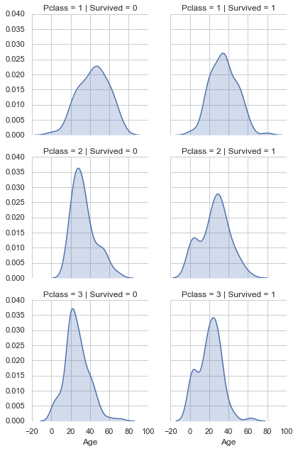

```python
g = sns.FacetGrid(titanic, col="Survived", row="Pclass")
g.map(sns.kdeplot, "Age", shade=True)
sns.despine(left=True, bottom=True)
plt.show()
```

When subsetting data using two conditions, the rows in the grid represented one condition while the columns represented another. We can express a third condition by generating multiple plots on the same subplot in the grid and color them differently. Thankfully, we can add a condition just by setting the hue parameter to the column name from the dataframe.

Let's add a new condition to the grid of plots we generated in the last step and see what this grid of plots would look like.

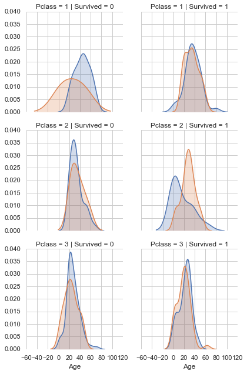

```python
g = sns.FacetGrid(titanic, col="Survived", row="Pclass", hue="Sex", size=3)
g.map(sns.kdeplot, "Age", shade=True)
sns.despine(left=True, bottom=True)
plt.show()
```

Now that we're coloring plots, we need a legend to keep track of which value each color represents.

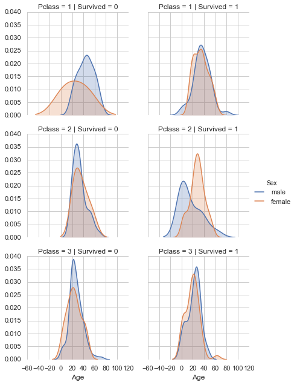

```python
g = sns.FacetGrid(titanic, col="Survived", row="Pclass", hue="Sex", size=3)
g.map(sns.kdeplot, "Age", shade=True)
g.add_legend()
sns.despine(left=True, bottom=True)
plt.show()
```

### Recap

Importing the seaborn module

`import seaborn as sns`

Creating a distribution plot

`sns.distplot(titanic['Fare'])`

Creating a kernel density plot

`sns.kdeplot(titanic['Fare'], shade=True)`

Shading underneath the curve of a kernel density plot

`sns.kdeplot(titantic['Fare'], shade=True)`

Setting the Seaborn Style Sheet:

`sns.set_style("white")`

Removing the Spines (default = remove top and right)

`sns.despine(left=True, bottom=True)`

Generating a grid of data containing a subset of the data for different values:

`g = sn.Facetgrid(titanic, col = 'Pclass', size = 6)`

Generating a grid of data with multiple subsets of the data:

`g = sns.Facetgrid(titanic, col = 'Pclass', row = 'Survived', size = 6)`

Adding different colors for unqiue values using hue:

`g = sns.Facetgrid(titanic, col = 'Pclass', row = 'Survived', hue = 'Sex', size = 6)`

Use a grid of data and map it onto a Seaborn object.

### Concepts

- Seaborn:
  - Is built on top of matplotlib.
  - Has good support for more complex plots.
  - Attractive default styles.
  - Integrates well with the pandas library.
- Seaborn creates a matplotlib figure or adds to the current existing figure.
- Seaborn stylesheets:
  - darkgrid: Coordinate grid displayed, dark background color.
  - whitegrid: Coordinate grid displayed, white background color.
  - dark: Coordinate grid hidden, dark background color.
  - white: Coordinate grid hidden, white background color.
  - ticks: Coordinate grid hidden, white background color, ticks visible.

### More resources:

Seaborn Gallery: https://seaborn.pydata.org/examples/index.html

Python Data Science Handbook (Vanderplas): https://jakevdp.github.io/PythonDataScienceHandbook/index.html

Visualization with Matplotlib

- Simple Line Plots
- Simple Scatter Plots
- Visualizing Errors
- Density and Contour Plots
- Histograms, Binnings, and Density
- Customizing Plot Legends
- Customizing Colorbars
- Multiple Subplots
- Text and Annotation
- Customizing Ticks
- Customizing Matplotlib: Configurations and Stylesheets
- Three-Dimensional Plotting in Matplotlib
- Geographic Data with Basemap
- Visualization with Seaborn
- Further Resources